# Biostat 200C Homework 3

Due May 5 @ 11:59PM

Cyrene Arputhasamy

To submit homework, please upload both Rmd and html files to BruinLearn by the deadline.

## Q1. Concavity of Poisson regression log-likelihood

Let $Y_1,\ldots,Y_n$ be independent random variables with $Y_i \sim \text{Poisson}(\mu_i)$ and $\log \mu_i = \mathbf{x}_i^T \boldsymbol{\beta}$, $i = 1,\ldots,n$.

### Q1.1 Log-likelihood of Poisson regression

Write down the log-likelihood function.

Given the $n$ independent data points $(y_i, \mathbf{x}_i)$, $i=1,\ldots,n$, the log-likelihood is
$$\begin{eqnarray*}
\ell(\boldsymbol{\beta}) &=& \sum_i y_i \log \mu_i - \mu_i -
\log y_i! \\
&=& \sum_i y_i \cdot \mathbf{x}_i^T \boldsymbol{\beta} -
e^{\mathbf{x}_i^T \boldsymbol{\beta}} - \log y_i!
\end{eqnarray*}$$

### Q1.2 Gradient and Hessian of the log-likelihood

Derive the gradient vector and Hessian matrix of the log-likelhood function with respect to the regression coefficients $\boldsymbol{\beta}$.

$$\begin{eqnarray*}
\ell(\boldsymbol{\beta}) &=& \sum_i y_i \log \mu_i - \mu_i -
\log y_i! \\
\nabla_\beta(\mathbf{x}_i^T \boldsymbol{\beta}) &=&
\nabla_\beta(\mathbf{x}_{i0} \beta_0 + \mathbf{x}_{i1} \beta_1 + \cdots
+ \mathbf{x}_{ip} \beta_p) = \mathbf{x}_i \\
\nabla_\beta \ell(\cdot) &=& \sum_i y_i(\nabla_\beta
\mathbf{x}_i^T \boldsymbol{\beta}) - \nabla_\beta (e^{\mathbf{x}_i^T
\boldsymbol{\beta}}) - \nabla_\beta (\log y_i!)\\
&=& \sum_i y_i \mathbf{x}_i - e^{\mathbf{x}_i^T
\boldsymbol{\beta}} \mathbf{x}_i \\
\end{eqnarray*}$$

Therefore the Hessian matrix with respect to the regression coefficients $\boldsymbol{\beta}$ is:

$$\begin{eqnarray*}
\nabla_\beta(\frac{\partial \ell(\cdot)}{\partial \beta}) &=&
\sum_i \nabla_\beta(y_i \mathbf{x}_i - e^{\mathbf{x}_i^T
\boldsymbol{\beta}} \mathbf{x}_i) \\
&=& - \sum_i e^{\mathbf{x}_i^T \boldsymbol{\beta}} \mathbf{x}_i
\mathbf{x}_i^T \\
\end{eqnarray*}$$

### Q1.3 Negative Hessian is PSD

Show that the log-likelihood function of the log-linear model is a concave function in regression coefficients $\boldsymbol{\beta}$. (Hint: show that the negative Hessian is a positive semi-definite matrix.)

Given the hessian from above, the negative hessian is:
$$\sum_i e^{\mathbf{x}_i^T \boldsymbol{\beta}} \mathbf{x}_i \mathbf{x}_i^T$$
which is always positive because $e^{\mathbf{x}_i^T \boldsymbol{\beta}}$ is always positive.

### Q1.4 Deviance

Show that for the fitted values $\widehat{\mu}_i$ from maximum likelihood estimates
$$\sum_i \widehat{\mu}_i = \sum_i y_i.$$
Therefore the deviance reduces to
$$D = 2 \sum_i y_i \log \frac{y_i}{\widehat{\mu}_i}.$$

$$\begin{eqnarray*}
D &=& 2 \log \frac{L (\mathbf{b}_{max})}{L(\mathbf{b})} =
2[\ell(\mathbf{b}_{max})- \ell(\mathbf{b})] \\
&=& 2 \sum_i [y_i \log(y_i) - y_i] - 2 \sum_i [y_i \log
(\widehat{\mu}_i) - \widehat{\mu}_i] \\
&=& 2 \sum_i [y_i \log(y_i / \widehat{\mu}_i) - (y_i -
\widehat{\mu}_i)] \\
&=& 2 \sum_i y_i \log(y_i / \widehat{\mu}_i)
\end{eqnarray*}$$

## Q2. Show negative binomial distribution mean and variance

Recall the probability mass function of negative binomial distribution is
$$\mathbb{P}(Y = y) = \binom{y + r - 1}{r - 1} (1 - p)^r p^y, \quad y = 0,
1, \ldots$$
Show $\mathbb{E}Y = \mu = rp / (1 - p)$ and $\operatorname{Var} Y = r p / (1 - p)^2$.

### Expectation of negative binomial

$$\begin{eqnarray*}
\mathbb{E}Y &=& \sum_{y=0}^\infty y \binom{y + r - 1}{r - 1} (1
- p)^r p^y \\
&=& \sum_{y=0}^\infty y \binom{y + r - 1}{y} (1 - p)^r p^y \\
&=& \sum_{y=1}^\infty \frac{(y + r - 1)!}{(y - 1)!(r - 1)!} (1 -
p)^r p^y \\
&=& \sum_{y=1}^\infty \binom{y + r -1}{y - 1} (1 - p)^r p^y \\
\end{eqnarray*}$$

If we re-parameterize $z = y - 1$, the sum becomes:

because everything inside the summation is another negative binomial pmf, so the sum over $z = 0$ to $\infty$ is $1$.

### Variance of negative binomial

$$\begin{eqnarray*}
\mathbb{E}(Y^2) &=& \sum_{y=0}^\infty y^2 \binom{y + r - 1}{r -
1} (1 - p)^r p^y \\
&=& \sum_{y=0}^\infty y^2 \binom{y + r - 1}{y} (1 - p)^r p^y \\
&=& \sum_{y=1}^\infty y^2 \frac{(y + r - 1)!}{y! (r - 1)!} (1 -
p)^r p^y \\
&=& \sum_{y=1}^\infty y \frac{(y + r -1)!}{(y - 1)! (r - 1)!} (1
- p)^r p^y \\
&=& \sum_{y = 0}^\infty (y + 1) \frac{(y + r)!}{y! (r - 1)!} (1
- p)^r p^{y+1} \\
&=& \sum_{y = 0}^\infty y \frac{(y + r)!}{y! (r - 1)!} (1 - p)^r
p^{y+1} + \sum_{y = 0}^\infty \frac{(y + r)!}{y! (r - 1)!} (1 - p)^r
p^{y+1} \\
&=& \sum_{y = 1}^\infty \frac{(y + r)!}{(y - 1)! (r - 1)!} (1 -
p)^r p^{y+1} + \sum_{y = 0}^\infty \frac{(y + r)!}{y! (r - 1)!} (1 -
p)^r p^{y+1} \\
&=& \sum_{y = 0}^\infty \frac{(y + r + 1)!}{y! (r - 1)!} (1 -
p)^r p^{y+2} + \sum_{y = 0}^\infty \frac{(y + r)!}{y! (r - 1)!} (1 -
p)^r p^{y+1} \\
\end{eqnarray*}$$

We can then solve each term individually. First term:

Second term:

$$\begin{eqnarray*}
\sum_{y = 0}^\infty \frac{(y + r)!}{y! (r - 1)!} (1 - p)^r p^{y+1}
&=& \sum_{y = 0}^\infty \frac{(r + 1 + y - 1)!}{y!(r - 1)!}(1 -
p)^r p^{y+1} \\
&=& \sum_{y = 0}^\infty \frac{(r + 1 + y - 1)!}{y!(r -
1)!}\frac{(r + 1 - 1)!}{(r + 1 - 1)!}(1 - p)^r p^{y+2} \\
&=& \frac{rp}{1 - p} \sum_{y = 0}^\infty \binom{r + 1 + y -
1}{y}(1 - p)^{r+1} p^{y} \\
&=& \frac{rp}{1 - p}
\end{eqnarray*}$$

Then also using the expectation we calculated earlier $\mathbb{E}Y = \mu = rp / (1 - p)$, we can compute the variance:

## Q3. ELMR Chapter 5 Exercise 5 (page 100)

The `dvisits` data comes from the Australian Health Survey of 1977–1978 and consist of 5190 single adults where young and old have been oversampled.

```r
library(faraway)
library(dplyr)
```

```r
library(ggplot2)
dvisits %>%
 head(5)
```

```
##   sex  age  agesq income levyplus freepoor freerepa illness actdays hscore
## 1   1 0.19 0.0361   0.55        1        0        0       1       4      1
## 2   1 0.19 0.0361   0.45        1        0        0       1       2      1
## 3   0 0.19 0.0361   0.90        0        0        0       3       0      0
## 4   0 0.19 0.0361   0.15        0        0        0       1       0      0
## 5   0 0.19 0.0361   0.45        0        0        0       2       5      1
##   chcond1 chcond2 doctorco nondocco hospadmi hospdays medicine prescrib
## 1       0       0        1        0        0        0        1        1
## 2       0       0        1        0        0        0        2        1
## 3       0       0        1        0        1        4        2        1
## 4       0       0        1        0        0        0        0        0
## 5       1       0        1        0        0        0        3        1
##   nonpresc
## 1        0
## 2        1
## 3        1
## 4        0
## 5        2
```

### 5.1

Make plots which show the relationship between the response variable, `doctorco`, and the potential predictors, `age` and `illness`.

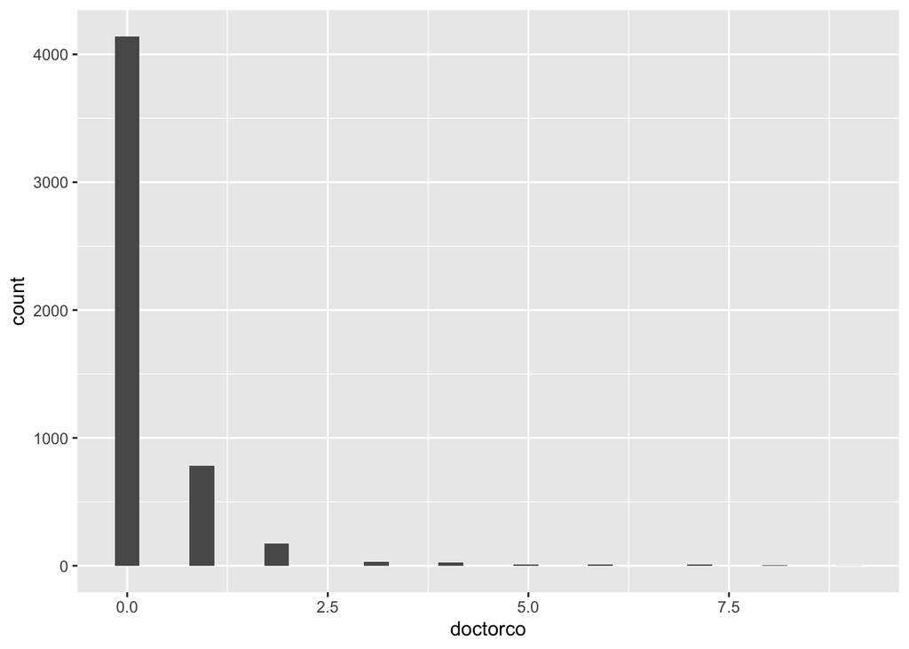

```r
ggplot(dvisits, aes(x=doctorco)) + geom_histogram()
```

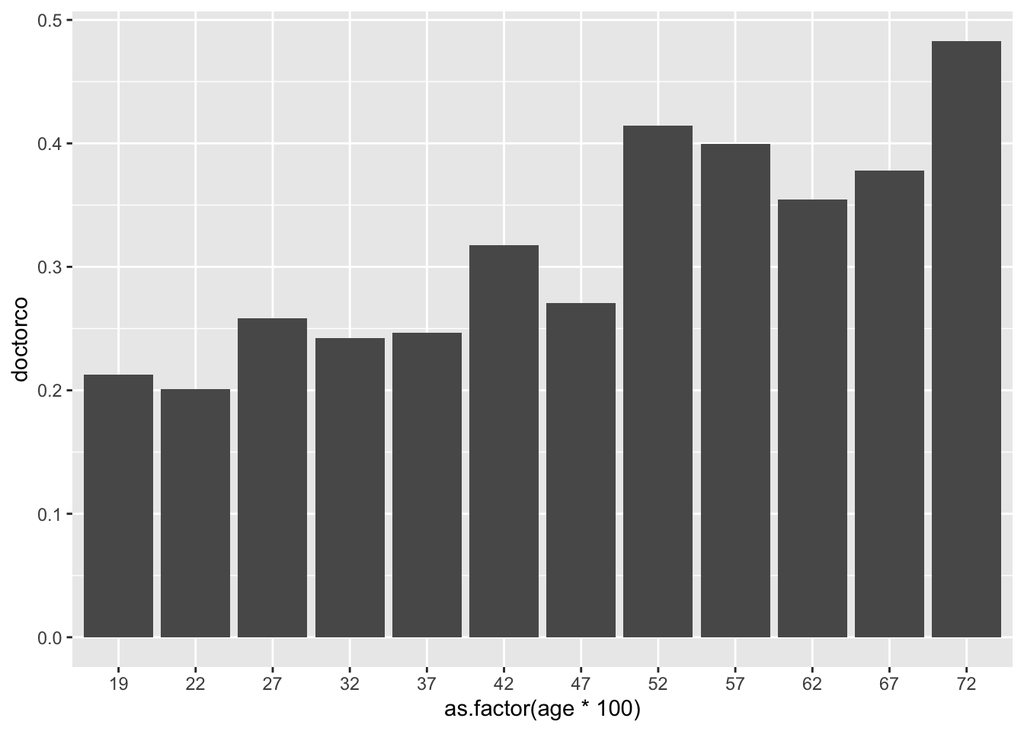

```r
(plot1 <- ggplot(dvisits, aes(x=as.factor(age*100), y=doctorco)) + geom_bar(position = "dodge", stat = "summary", fun = "mean"))
```

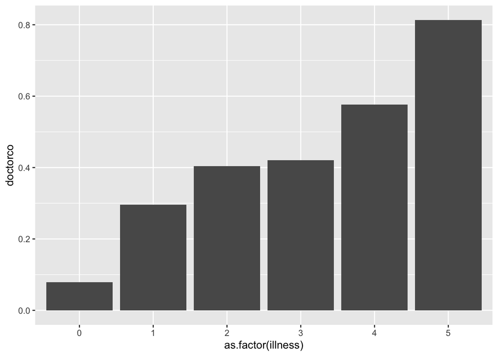

```r
(plot2 <- ggplot(dvisits, aes(x=as.factor(illness), y=doctorco)) + geom_bar(position = "dodge", stat = "summary", fun = "mean"))
```

```r
#grid.arrange(plot1, plot2, ncol = 2)
```

It appears that the average number of consultation with a doctor or specian in the past 2 weeks (`doctorco`) increases with `age` and with the number of illnesses in the past 2 weeks (`illness`).

### 5.2

Combine the predictors `chcond1` and `chcond2` into a single three-level factor. Make an appropriate plot showing the relationship between this factor and the response. Comment.

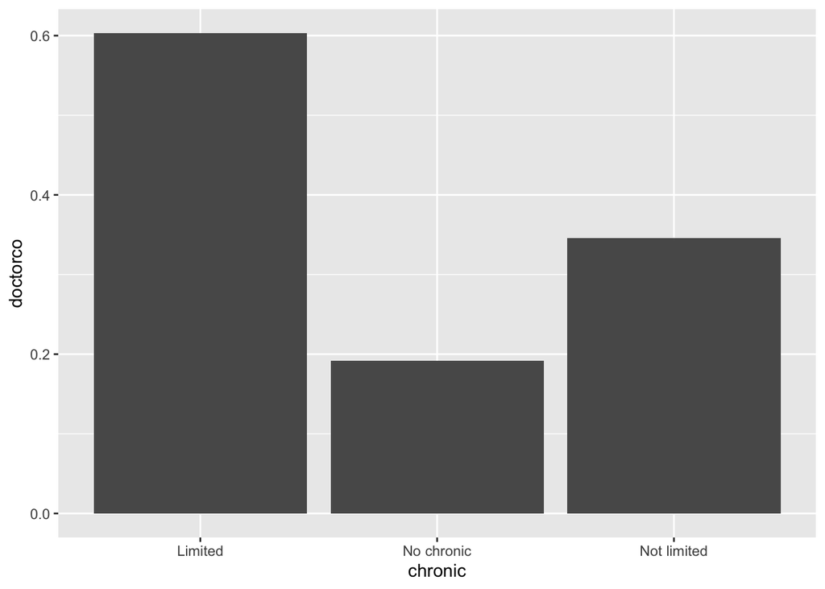

```r
library(dplyr)
dvisits1 <- dvisits %>%
  mutate(chronic = case_when(
    chcond1 == 1 ~ "Not limited",
    chcond2 == 1 ~ "Limited",
    .default = "No chronic"
  ))
dvisits1$chronic <- as.factor(dvisits1$chronic)
ggplot(dvisits1, aes(x=chronic, y=doctorco)) + geom_bar(position = "dodge", stat = "summary", fun = "mean")
```

On average, those with chronic conditions who are also limited in activity have more doctor appointments than those with chronic conditions without limited activity, and even more than those without chronic conditions. There seems to be a progressive trend.

### 5.3

Build a Poisson regression model with `doctorco` as the response and `sex`, `age`, `agesq`, `income`, `levyplus`, `freepoor`, `freerepa`, `illness`, `actdays`, `hscore` and the three-level condition factor (`chronic`) as possible predictor variables. Considering the deviance of this model, does this model fit the data?

```r
library(gtsummary)
modp <- glm(doctorco ~ sex + age + agesq + income + levyplus + freepoor + freerepa + illness + actdays + hscore + chronic, family = poisson, data = dvisits1)
modp %>%
  tbl_regression(exponentiate = TRUE) %>%
  add_glance_table(include = c(deviance, df.residual))
```

| **Characteristic** | **IRR**<sup>1</sup> | **95% CI**<sup>1</sup> | **p-value** |
| --- | --- | --- | --- |
| sex | 1.17 | 1.05, 1.31 | 0.005 |
| age | 2.88 | 0.40, 20.3 | 0.3 |
| agesq | 0.43 | 0.05, 3.57 | 0.4 |
| income | 0.81 | 0.68, 0.97 | 0.020 |
| levyplus | 1.13 | 0.98, 1.30 | 0.086 |
| freepoor | 0.64 | 0.45, 0.90 | 0.014 |
| freerepa | 1.08 | 0.90, 1.30 | 0.4 |
| illness | 1.21 | 1.16, 1.25 | <0.001 |
| actdays | 1.14 | 1.12, 1.15 | <0.001 |
| hscore | 1.03 | 1.01, 1.05 | 0.003 |
| chronic |  |  |  |
| Limited | — | — |  |
| No chronic | 0.87 | 0.74, 1.02 | 0.090 |
| Not limited | 0.97 | 0.85, 1.12 | 0.7 |
| Deviance | 4,380 |  |  |
| Residual df | 5,177 |  |  |

<sup>1</sup> IRR = Incidence Rate Ratio, CI = Confidence Interval

Since the deviance is lower than the residual degrees of freedom, it seems that the model does generally fit the data.

### 5.4

Plot the residuals and the fitted values — why are there lines of observations on the plot? Make a QQ plot of the residuals and comment.

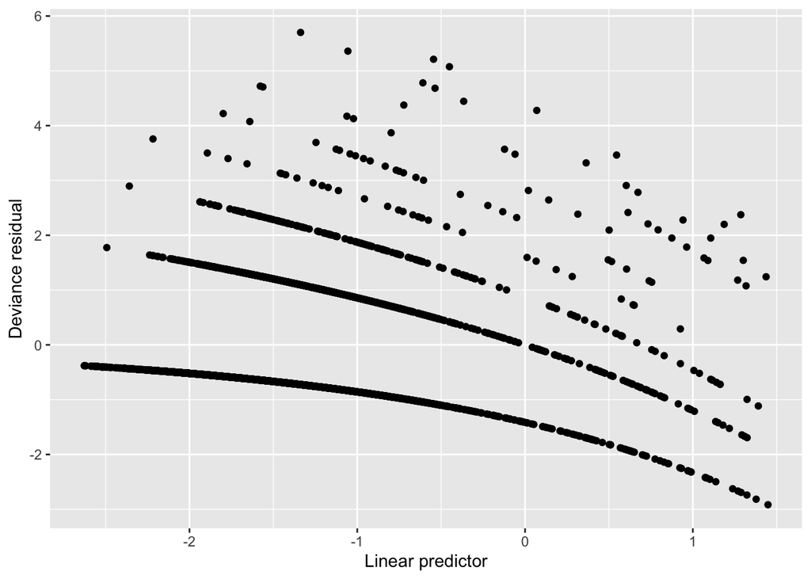

```r
dvisits1 %>%
  mutate(devres  = residuals(modp, type = "deviance"),
         linpred = predict(modp, type = "link")) %>%
  ggplot +
  geom_point(mapping = aes(x = linpred, y = devres)) +
  labs(x = "Linear predictor", y = "Deviance residual")
```

There are lines in the fitted-residuals plot because the dependent variable `doctorco` is discrete. Every case of the values of `doctorco` has a prediction. The lines curve because the x-axis is the log scale. As `doctorco` varies, the curves rise by integral amounts. Exponentiating them gives a set of quasi-parallel curves.

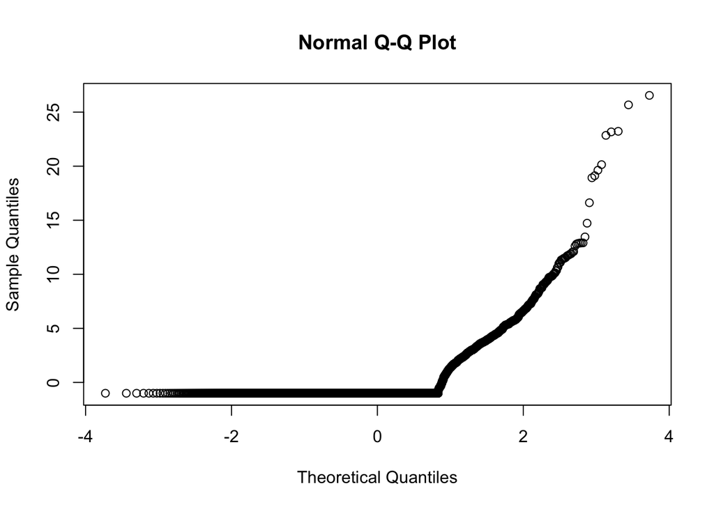

```r
qqnorm(modp$residuals)
```

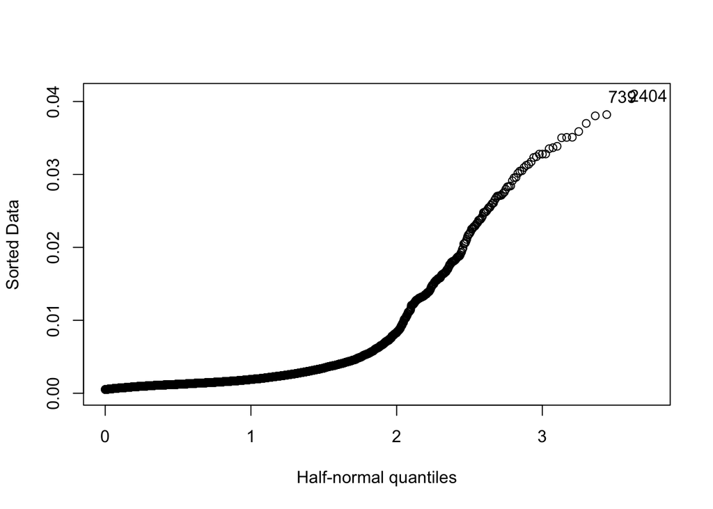

```r
halfnorm(hatvalues(modp))
```

```r
dvisits1 %>%
  slice(c(739, 2404))
```

```
##      sex  age  agesq income levyplus freepoor freerepa illness actdays hscore
## 739    1 0.67 0.4489   0.35        1        0        0       5      14     10
## 2404   1 0.72 0.5184   0.25        1        0        0       5      14      9
##      chcond1 chcond2 doctorco nondocco hospadmi hospdays medicine prescrib
## 739        1       0        7       10        3        7        6        6
## 2404       0       1        0        0        0        0        4        4
##      nonpresc     chronic
## 739         0 Not limited
## 2404        0     Limited
```

The QQ plot is not ideal because we don’t expect to have a normal distribution in this case. The halfnormal plot indicates some potential outliers.

### 5.5

Use a step-wise AIC-based model selection method. What sort of person would be predicted to visit the doctor the most under your selected model?

```r
(modp2 <- step(modp, trace = FALSE))
```

```
##
## Call:  glm(formula = doctorco ~ sex + age + income + levyplus + freepoor +
##     illness + actdays + hscore + chronic, family = poisson, data = dvisits1)
##
## Coefficients:
##        (Intercept)                 sex                 age              income
##           -1.93017             0.16200             0.35513            -0.19981
##           levyplus            freepoor             illness             actdays
##            0.08369            -0.46960             0.18610             0.12661
##             hscore   chronicNo chronic  chronicNot limited
##            0.03112            -0.15889            -0.03779
##
## Degrees of Freedom: 5189 Total (i.e. Null);  5179 Residual
## Null Deviance:       5635
## Residual Deviance: 4381  AIC: 6735
```

According to the signs of the coefficients, the type of person predicted to visit the doctor the most under the model selected by AIC is someone who is female, older, covered by private health insurance fund (though this doesn’t seem to impact that much), has a higher number of illnesses in the past 2 weeks, increased number of days of reduced activity in the past weeks due to illness or injury, with a higher score on a health questionnaire using the Goldberg method, and with some kind of chronic condition whether it limits activity or not. An increase in income seems to be related to going to the doctor less often than otherwise.

### 5.6

For the last person in the dataset, compute the predicted probability distribution for their visits to the doctor, i.e., give the probability they visit 0, 1, 2, etc. times.

```r
(l <- dvisits1 %>% slice(5190)) # last person in the data set
```

```
##      sex  age  agesq income levyplus freepoor freerepa illness actdays hscore
## 5190   0 0.72 0.5184   0.25        0        0        1       0       0      0
##      chcond1 chcond2 doctorco nondocco hospadmi hospdays medicine prescrib
## 5190       0       0        0        0        0        0        0        0
##      nonpresc    chronic
## 5190        0 No chronic
```

```r
dpois(0, predict(modp, data.frame(l), type = "response")) # probability that this person visits the doctor 0 times
```

```
## [1] 0.8578005
```

```r
dpois(1, predict(modp, data.frame(l), type = "response")) # P visit 1 time ...
```

```
## [1] 0.1315726
```

```r
dpois(2, predict(modp, data.frame(l), type = "response"))
```

```
## [1] 0.01009055
```

```r
dpois(3, predict(modp, data.frame(l), type = "response"))
```

```
## [1] 0.0005159087
```

```r
dpois(4, predict(modp, data.frame(l), type = "response"))
```

```
## [1] 1.9783e-05
```

```r
dpois(5, predict(modp, data.frame(l), type = "response"))
```

```
## [1] 6.068779e-07
```

### 5.7

Tabulate the frequencies of the number of doctor visits. Compute the expected frequencies of doctor visits under your most recent model. Compare the observed with the expected frequencies and comment on whether it is worth fitting a zero-inflated count model.

```r
dvisits1 %>% count(doctorco)
```

```
##    doctorco    n
## 1         0 4141
## 2         1  782
## 3         2  174
## 4         3   30
## 5         4   24
## 6         5    9
## 7         6   12
## 8         7   12
## 9         8    5
## 10        9    1
```

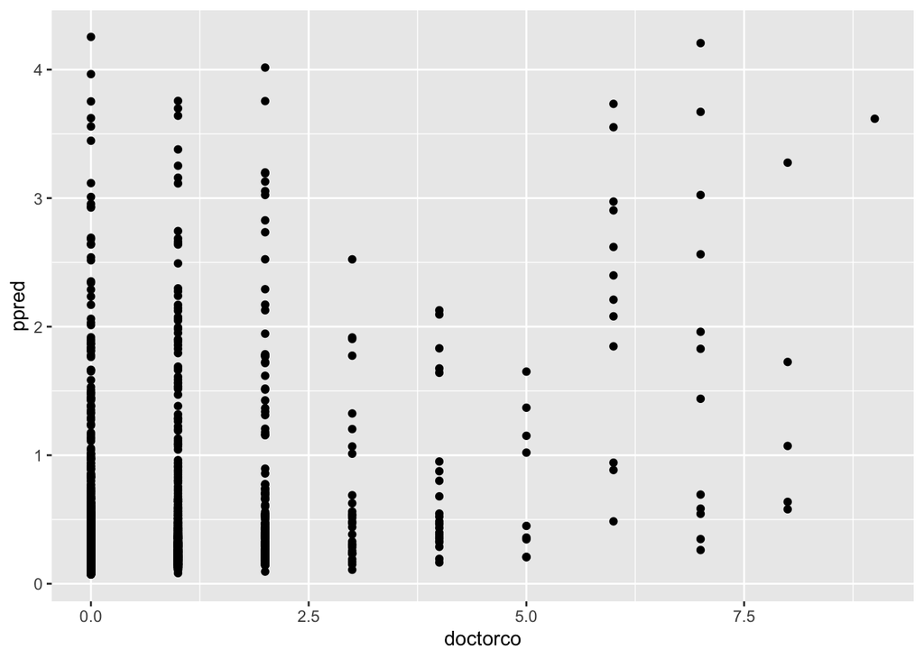

```r
ppred <- predict(modp, dvisits1, type = "response")
dvisits1 <- dvisits1 %>% mutate(prediction = ppred)
(p1 <- ggplot(dvisits1, aes(x=doctorco, y = ppred)) + geom_point())
```

### 5.8

Fit a comparable (Gaussian) linear model and graphically compare the fits. Describe how they differ.

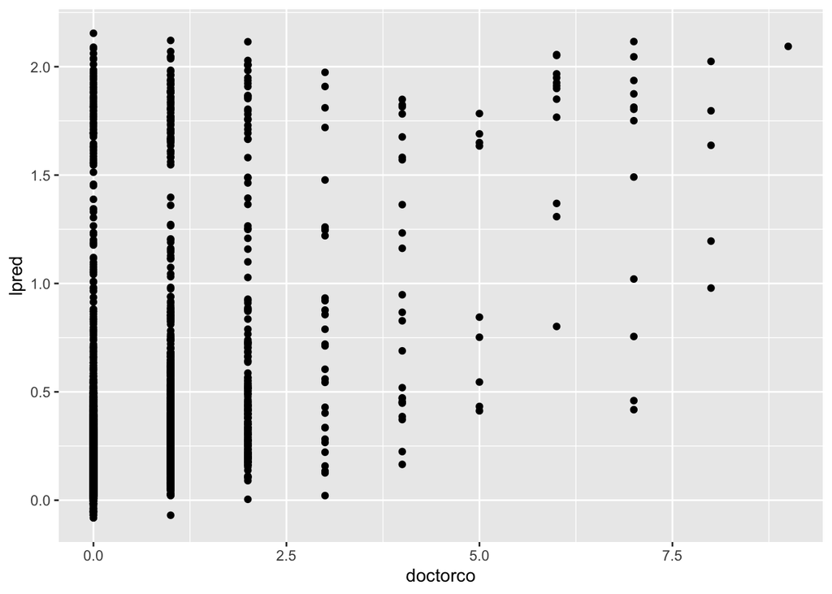

```r
lm <- lm(doctorco ~ sex + age + income + levyplus + freepoor + illness + actdays + hscore + chronic, dvisits1)
lpred <- predict(lm, dvisits1, type = "response")
dvisits1 <- dvisits1 %>% mutate(prediction2 = lpred)
(p2 <- ggplot(dvisits1, aes(x=doctorco, y = lpred)) + geom_point())
```

## Q4. Uniform association

For the uniform association when all two-way interactions are included, i.e.,
$$\log \mathbb{E}Y_{ijk} = \log p_{ijk} = \log n + \log p_i + \log p_j +
\log p_k + \log p_{ij} + \log p_{ik} + \log p_{jk}.$$

Prove the odds ratio (or log of odds ratio) across all stratum $k$
$$\log
\frac{\mathbb{E}Y_{11k}\mathbb{E}Y_{22k}}{\mathbb{E}Y_{12k}\mathbb{E}Y_{21k}}$$

is a constant, i.e., the estimated effect of the interaction term “i:j” in the uniform association model

**Solution**

$$\begin{eqnarray*}
\log
\frac{\mathbb{E}Y_{11k}\mathbb{E}Y_{22k}}{\mathbb{E}Y_{12k}\mathbb{E}Y_{21k}}
&=& \log{\mathbb{E}Y_{11k}\mathbb{E}Y_{22k}} -
\log{\mathbb{E}Y_{12k}\mathbb{E}Y_{21k}} \\
&=& \log\mathbb{E}Y_{11k} + \log\mathbb{E}Y_{22k} -
\log\mathbb{E}Y_{12k} - \log\mathbb{E}Y_{21k} \\
&=& \log n + \log p_{i=1} + \log p_{j=1} + \log p_k + \log
p_{11} + \log p_{1k} + \log p_{1k} \\
&\quad& + \log n + \log p_2 + \log p_2 + \log p_k + \log p_{22}
+ \log p_{2k} + \log p_{2k} \\
&\quad& - (\log n + \log p_1 + \log p_2 + \log p_k + \log p_{12}
+ \log p_{1k} + \log p_{2k}) \\
&\quad& - (\log n + \log p_2 + \log p_1 + \log p_k + \log p_{21}
+ \log p_{2k} + \log p_{1k}) \\
\end{eqnarray*}$$

Most of the terms cancel out resulting in:

$$= \log p_{11} + \log p_{22} - \log p_{12} - \log p_{21} = \log
\frac{p_{11}p_{22}}{p_{12}p_{21}}$$
which is not dependent on $k$, so the log-odds is constant in all stratum $k$.